# Martinez Assignment 1

## Model Building and Fitment

Now we will build a linear model. This will be the de facto ordinary least squares regression.

The function is as follows:

$$ \hat{y} = \beta_0 + \beta_1 x_1 + \epsilon $$

In order to ensure model accuracy, I'll use the coefficient of determination, or $R^2$

The function is as follows:

$$SS_{tot} = \sum_{i}(y_i - \bar{y})^2$$$$SS_{res} = \sum_{i} e^2_i$$$$R^2 = 1 - \frac{SS_{res}}{SS_{tot}}$$

```python
model = LinearRegression()

model.fit(X_train, y_train)
```

```
LinearRegression(copy_X=True, fit_intercept=True, n_jobs=None, normalize=False)
```

```python
# These are the scaled coefs. While they are correct, they are a bit difficult to interpret.

model.coef_
```

```
array([228853.64224356, 164435.84671342, 121054.20052859,   1961.41011388,
       151825.60512927])
```

```python
# We can unscale them for a more business-friendly explanation.

coefs2 = pd.DataFrame(model.coef_/scl.scale_)
coefs2
```

|  | 0 |
| --- | --- |
| 0 | 21.474641 |
| 1 | 165869.451531 |
| 2 | 120364.195574 |
| 3 | 1589.455516 |
| 4 | 15.297818 |

With our coefficients now computed, we can view the actual equation that we have built:

$$\hat{y} = 1231277.0248333374 + 228853.64224356 x_1 + 164435.84671342 x_2 + 121054.20052859 x_3 + 1961.41011388 x _4 + 151825.60512927 x_5$$

```python
coefficients = np.true_divide(model.coef_,  scl.scale_)
intercept = model.intercept_ - np.dot(coefficients, scl.mean_)
```

```python
# The intercept is what we expect mean price to be, or when X_i = 0. This is also scaled so we can also print the non-scaled

print(f'Scaled int: {model.intercept_}')
print(f'Raw int: {intercept}')
```

```
Scaled int: 1231277.0248333374
Raw int: -2633590.115971513
```

```python
y_hat = model.predict(X_test)
```

## Model Testing

First I'll do it programatically using the functions for MSE and R2.

```python
mse = mean_squared_error(y_test, y_hat)
r2 = r2_score(y_test, y_hat)

print(f'Mean Square error: {mse}')
print(f'R2 score: {r2}')
```

```
Mean Square error: 9943170477.493637
R2 score: 0.9198377011002263
```

```python
print(f'RMSE Error: {sqrt(mse)}')
```

```
RMSE Error: 99715.44753694703
```

## Plot the predictions

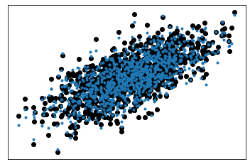

```python
# plot the graph. This example refers to the income.

plt.scatter(X_test[0], y_test, color = "black")


plt.plot(X_test[0], y_hat, '.')
plt.xticks(())
plt.yticks(())
plt.show()
```

Here the $R^2$ and mse can be calculated manually:

```python
SSR = ((y_test - y_hat) ** 2).sum()
SST = ((y_test - y_test.mean()) ** 2).sum()
```

```python
R_manual = 1-(SSR/SST)
```

```python
r2_adjusted = 1 - (1-R_manual)*(len(y_test)-1)/(len(y_test)-X_test.shape[1]-1)
```

```python
print(f'R-squared by hand: {R_manual}')
print(f'Adjusted R2: {r2_adjusted}')
```

```
R-squared by hand: 0.9198377011002263
Adjusted R2: 0.9194344702204488
```

## Reference model with statsmodels

Stats models provides a nice R-like summary of the coefficients so we'll take a look at that for p-values.

```python
X_const = sm.add_constant(X_train) # adding a constant

mod = sm.OLS(y_train, X_train).fit()
predictions = mod.predict(X_test)

print(mod.summary())
```

```
                                 OLS Regression Results
=======================================================================================
Dep. Variable:                  Price   R-squared (uncentered):                   0.071
Model:                            OLS   Adj. R-squared (uncentered):              0.070
Method:                 Least Squares   F-statistic:                              60.91
Date:                Sun, 06 Sep 2020   Prob (F-statistic):                    2.35e-61
Time:                        20:12:50   Log-Likelihood:                         -61783.
No. Observations:                4000   AIC:                                  1.236e+05
Df Residuals:                    3995   BIC:                                  1.236e+05
Df Model:                           5
Covariance Type:            nonrobust
==============================================================================
                 coef    std err          t      P>|t|      [0.025      0.975]
------------------------------------------------------------------------------
0           2.315e+05   1.96e+04     11.787      0.000    1.93e+05     2.7e+05
1           1.656e+05   1.96e+04      8.461      0.000    1.27e+05    2.04e+05
2           1.143e+05   2.22e+04      5.148      0.000    7.08e+04    1.58e+05
3           5099.5414   2.21e+04      0.231      0.817   -3.82e+04    4.84e+04
4           1.567e+05   1.93e+04      8.127      0.000    1.19e+05    1.95e+05
==============================================================================
Omnibus:                        4.121   Durbin-Watson:                   0.013
Prob(Omnibus):                  0.127   Jarque-Bera (JB):                3.722
Skew:                           0.010   Prob(JB):                        0.156
Kurtosis:                       2.852   Cond. No.                         1.64
==============================================================================

Warnings:
[1] Standard Errors assume that the covariance matrix of the errors is correctly specified.
```

# Conclusion

Based on our model, we found that the coefficient of determination was around 91% which indicated quite a good fit.

For a single unit increase in income, the house price increases by 21.4. Number of rooms had a huge coefficient, indicating that for every additional room, the house price increased by 120,364 dollars. This makes sense since, aside from the regular rooms (kitchen, bedroom, dining room, etc), specialty rooms are only for luxury homes. Things such as wine cellars, second kitchens, game rooms, etc are likely to make up this large value.

Surprisingly to me, all regressors were significant except number of bedrooms. This did not really contribute to the model and could be removed. It's generally accepted that this is important since usually larger houses have more bedrooms. However, some of this impact could be within the "number of rooms" variable. It would be interesting to review the model variance without this value and try again.